# Introduction to Gene Expression -II

Mridula Nandakumar

2023-08-01

In this exercise, we will learn to analyse and interpret transcriptome data, focusing specifically on differential gene expression analysis. In the previous sessions, we downloaded publicly available data and used a RNA-seq pipeline that trimmed adapter sequences from the reads, checked quality and quantified the number of reads accounting for each transcript using kallisto. We pick up today’s session here, where we will look at differential gene expression between macrophages stimulated with salmonella typhimurium and the uninfected control. We will try to understand which processes are differentially regulated between the two conditions.

You need R and RStudio for this workshop. You can download the R installer with the following link; make sure to download the right installer for your operating system (Windows/Mac). If you have already R installed, make sure it is updated to the latest version (4.3) to ensure all packages function without any errors. https://ftp.acc.umu.se/mirror/CRAN/

RStudio can be downloaded from here: https://posit.co/download/rstudio-desktop/

Before we move further, let’s create a folder to work from. On the desktop, create a folder called csmb_rnaSeq and within it another folder called 6_dge. Ensure that the abundance.tsv files from the 6 samples and the metaData.txt files are present in the folder 6_dge. You can download these files from the github page for this workshop, present under the “6_dge” folder. What is contained in the input abundance files is transcript abundances, however this data needs to be converted into reads accounting for each gene expression (since multiple transcripts can account for a gene)

# A. Importing data and setting up

```r
#setting the working directory
setwd("~/Desktop/csmb_rnaSeq/6_dge/")

#importing the metaData.txt file
metaData <- read.table("metaData.txt", header = TRUE)

#setting up the file names of the abundance.tsv files that need to be imported
files <- paste(metaData$Run, "abundance.tsv", sep ="_")

#setting the name of each file to the sample
names(files) <- metaData$Sample

#loading the ensembl database for annotations
library(EnsDb.Hsapiens.v86)
#choosing the ensembl Human databse
edb <- EnsDb.Hsapiens.v86

#downloading information about the transcripts annotated in the human genome
TxDb <- transcripts(edb, columns = c(listColumns(edb , "tx"), "gene_name"), return.type="DataFrame")

#choosing only those columns that are of interest for us: "tx_id" (ensembl transcipt id) and "gene_id" (ensembl gene id)
Tx2Gene <- TxDb[,c("tx_id","gene_id")]

#tximport is a package to handle transcript abundances; loading this package
library(tximport)

#reading all 6 abundace files and matching the transript IDs with gene IDs
txi.kallisto.tsv <- tximport(files, type = "kallisto", tx2gene = Tx2Gene, ignoreTxVersion = TRUE)
```

```
## Note: importing `abundance.h5` is typically faster than `abundance.tsv`
```

```
## reading in files with read.delim (install 'readr' package for speed up)
```

```
## 1 2 3 4 5 6
## transcripts missing from tx2gene: 35624
## summarizing abundance
## summarizing counts
## summarizing length
```

```r
#what's in txi.kallisto.tsv; check with
#head(txi.kallisto.tsv)
```

# B. Differential gene expression (DGE):

We will be using Deseq2, an R package very popular for DE analsyis. Briefly, these packages run a generalised linear model to check if the patterns of expression observed are a consequence of the treatment or condition, as compared to the control. The reads counts need to be normalised to proceed with differential expression. Normalisation is a very critical aspect of gene expression analysis, without which DE analysis is pretty meaningless. It accounts for variability in the number of reads (library size/sequencing depth), gene length and RNA composition that can bias results towards larger libraries, longer and highly expressed genes. Deseq2 uses a method called “median of ratios” to carry out normalisation.

Now we will create an object that contains all the required input files and the generalised linear model we desire, in a format that is compatible with deseq2. We need to provide input information, along with the model to be run. For this run we are only using the infection condition as a variable.

```r
#loading the package
library(DESeq2)
#creating deseq object and specifying the variables for count data, metadata and the model
dds <- DESeqDataSetFromTximport(txi=txi.kallisto.tsv, colData = metaData, design = ~ Infection)
```

```
##   Note: levels of factors in the design contain characters other than
##   letters, numbers, '_' and '.'. It is recommended (but not required) to use
##   only letters, numbers, and delimiters '_' or '.', as these are safe characters
##   for column names in R. [This is a message, not a warning or an error]
```

```
## using counts and average transcript lengths from tximport
```

```r
#get an overview of the object
dds
```

```
## class: DESeqDataSet
## dim: 39076 6
## metadata(1): version
## assays(2): counts avgTxLength
## rownames(39076): ENSG00000000003 ENSG00000000005 ... ENSG00000283698
##   ENSG00000283700
## rowData names(0):
## colnames(6): cont_1 salm_1 ... cont_3 salm_3
## colData names(4): Run Individual Infection Sample
```

```r
#eliminating lowly expressed genes: retaining only those rows with count >=2 in at least 4 samples; this will hasten the analysis
keep <- rowSums(counts(dds) >= 2) >= 4

#updating dds to remove genes with low expression
dds <- dds[keep,]

#setting control as the reference level for further analysis
dds$Infection <- relevel(dds$Infection, ref = c("Non-infected"))

#calculating DE; this includes the normalisation step
dds.de <- DESeq(dds)
```

```
##   Note: levels of factors in the design contain characters other than
##   letters, numbers, '_' and '.'. It is recommended (but not required) to use
##   only letters, numbers, and delimiters '_' or '.', as these are safe characters
##   for column names in R. [This is a message, not a warning or an error]
```

```
## using 'avgTxLength' from assays(dds), correcting for library size
```

```
##   Note: levels of factors in the design contain characters other than
##   letters, numbers, '_' and '.'. It is recommended (but not required) to use
##   only letters, numbers, and delimiters '_' or '.', as these are safe characters
##   for column names in R. [This is a message, not a warning or an error]
```

To see what has happened at this step, let’s take a look at the reads before and after normalisation:

```r
#fetching raw counts that was used as input
head(counts(dds.de))
```

```
##                 cont_1 salm_1 cont_2 salm_2 cont_3 salm_3
## ENSG00000000003      3      2      2      4      1      9
## ENSG00000000419    585    538    809    260    665    448
## ENSG00000000457    442    531    270    422    304    675
## ENSG00000000460    192    139    194     87    150    110
## ENSG00000000938   2992   6840   9811   4367   5172   5008
## ENSG00000000971      3      4    129     74     23     38
```

```r
#fetching read counts after normalisation for comparison
head(counts(dds.de, normalized =T))
```

```
##                      cont_1      salm_1      cont_2      salm_2      cont_3
## ENSG00000000003    1.419396    1.292451    3.742305    8.515729    0.590108
## ENSG00000000419  411.814906  528.933608  569.427999  490.433906  592.010815
## ENSG00000000457  284.919924  535.128477  179.060095  832.978036  264.389260
## ENSG00000000460  156.732428  117.945700  136.314733  142.163024  155.302034
## ENSG00000000938 2113.245766 6378.295941 7007.276696 8312.205116 4755.924927
## ENSG00000000971    1.397376    2.043901  129.044453  172.186241   29.134322
##                     salm_3
## ENSG00000000003   12.52200
## ENSG00000000419  547.65556
## ENSG00000000457  912.66903
## ENSG00000000460  133.58983
## ENSG00000000938 6082.49573
## ENSG00000000971   54.14997
```

# C. Quality check of DE data:

We will now do some quality checks to see if the design and execution of the experiment worked. To do this, we will obtain clustering information from a PCA plot. The expectation is that samples from similar treatments or populations would be more alike to each other.

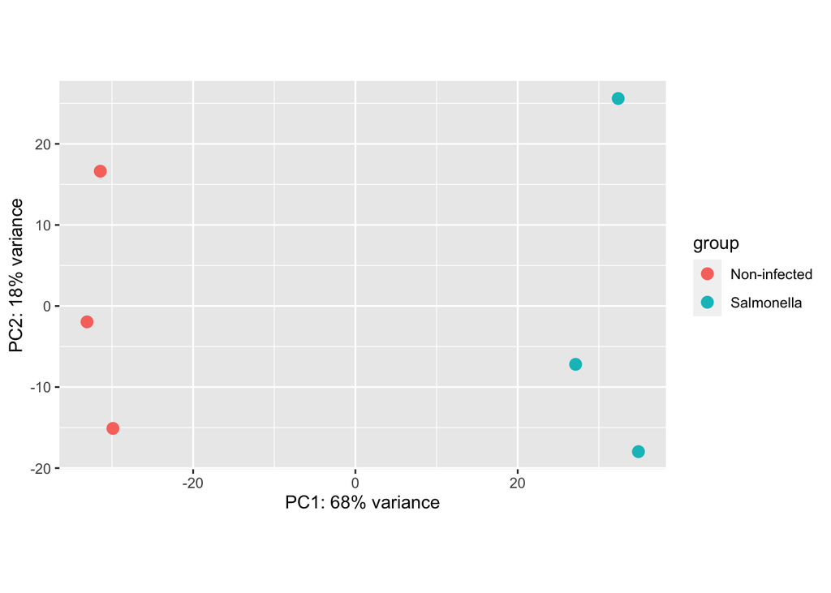

```r
#transforming the normalised read counts using regularised log
rld <- rlog(dds.de, blind=TRUE)

#PCA plot with Infection as the condition of interest
plotPCA(rld, intgroup="Infection")
```

Questions: 1. How does the PCA plot match your expectation from this experiment? What does PC1 and PC2 explain?

# D. Condition-specific analysis of DGE

Now that we are done with our QC, we can proceed with DE analysis for each condition. We start with Salmonella infections. By default, summary() takes the cut off as adjusted p-value <0.1. We will now specify that we want results that are signficant for padj <0.05. Look out for the differences in number of genes reported.

```r
#specifying the threshold for significance using the "alpha" parameter
res.salm <- results(dds.de, alpha=0.05, contrast = c("Infection", "Salmonella", "Non-infected"))
summary(res.salm)
```

```
##
## out of 16658 with nonzero total read count
## adjusted p-value < 0.05
## LFC > 0 (up)       : 2487, 15%
## LFC < 0 (down)     : 1978, 12%
## outliers [1]       : 50, 0.3%
## low counts [2]     : 1292, 7.8%
## (mean count < 5)
## [1] see 'cooksCutoff' argument of ?results
## [2] see 'independentFiltering' argument of ?results
```

```r
#getting a count of the number of genes with padj <0.05
sum(res.salm$padj < 0.05, na.rm=TRUE)
```

```
## [1] 4465
```

Questions:

1. How many genes are differentially expressed? OF that, how many are up-regualted and how many are down-regulated? We will now extract the significant genes for further analyses.

```r
#subsetting all significant genes into a separate object
res.salm.de <- subset(res.salm, res.salm$padj < 0.05)
```

You would have noticed that the entries are present as Ensmebl gene IDs (eg:ENSG00000139618) instead of gene names (eg:BRCA2), which is a bit meaningless to us. So additionally, we will also match the gene IDs to gene names, which maybe easier to read.

We will now proceed to map gene names to the ensembl gene IDs.

```r
#adding ensembl gene id (which is the rowname for res.salm.de) as a column
res.salm.de$gene_id <- rownames(res.salm.de)

#merging by the common column "ensembl_gene_id"
res.salm.de <- merge(as.data.frame(res.salm.de), unique(TxDb[,c ("gene_id", "gene_name")]), by="gene_id", all=F)

#sorting by padj
res.salm.de <- res.salm.de[order(res.salm.de$padj),]

#how res.salm.de looks like after merging and sorting
head(res.salm.de)
```

```
## DataFrame with 6 rows and 8 columns
##           gene_id  baseMean log2FoldChange     lfcSE      stat       pvalue
##       <character> <numeric>      <numeric> <numeric> <numeric>    <numeric>
## 1 ENSG00000184557  84614.50        8.15295  0.236524   34.4699 2.26781e-260
## 2 ENSG00000126353  17015.58        9.98595  0.366475   27.2487 1.72336e-163
## 3 ENSG00000117090  23552.14        9.04478  0.348906   25.9232 3.64290e-148
## 4 ENSG00000136689 120155.77        6.44700  0.265016   24.3268 1.01972e-130
## 5 ENSG00000122641   4662.62        9.04169  0.403142   22.4280 2.09653e-111
## 6 ENSG00000115009   5455.87        7.70808  0.349668   22.0440 1.09033e-107
##           padj   gene_name
##      <numeric> <character>
## 1 3.47337e-256       SOCS3
## 2 1.31975e-159        CCR7
## 3 1.85982e-144      SLAMF1
## 4 3.90450e-127       IL1RN
## 5 6.42211e-108       INHBA
## 6 2.78326e-104       CCL20
```

```r
#writing to a file; you can open the exported file in Excel for example
write.table(res.salm.de, "de_genes.tsv", row.names = F, col.names = T, sep="\t", quote = F)
```

We have all the necessary information to do make some interesting plots. We will use the R package ggplot2 to help make plots pretty.We will begin with visualising the global expression patterns and the extent of DE genes with the help of an MA plot.

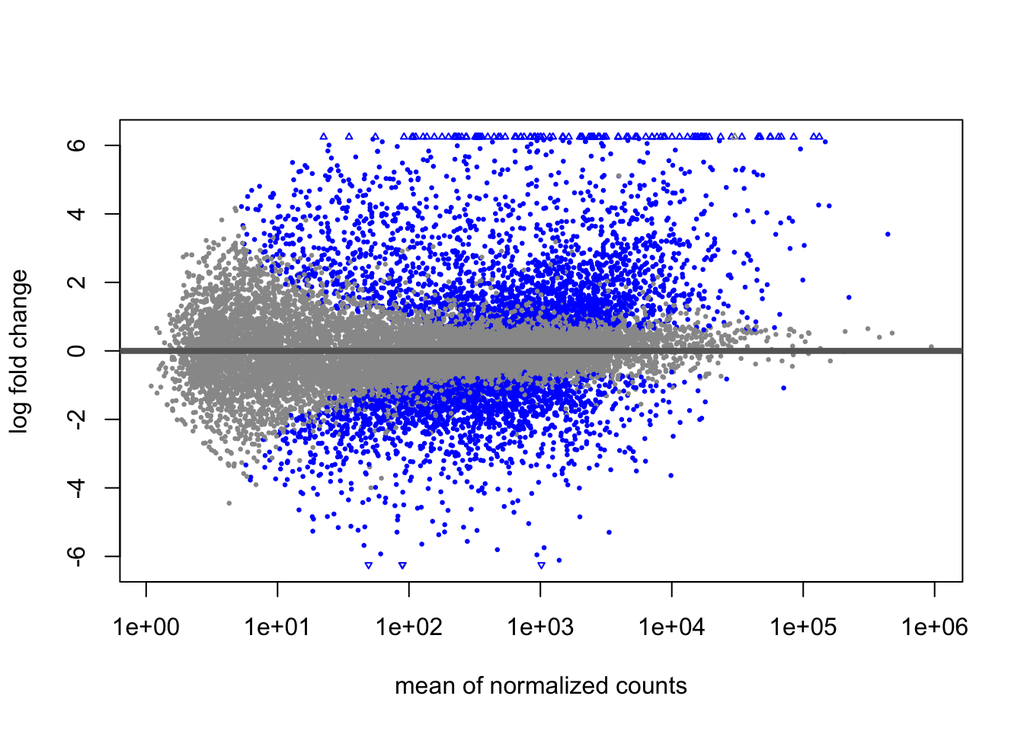

```r
library(ggplot2)

#MA plot for salmonella infection
plotMA(res.salm)
```

Questions:

1.. What are the most interesting genes?

Next we can present similar information in the form of a volcano plot. Since we have many genes that are DE, we can limit the number of points we highlight to log2 fold change >=2.

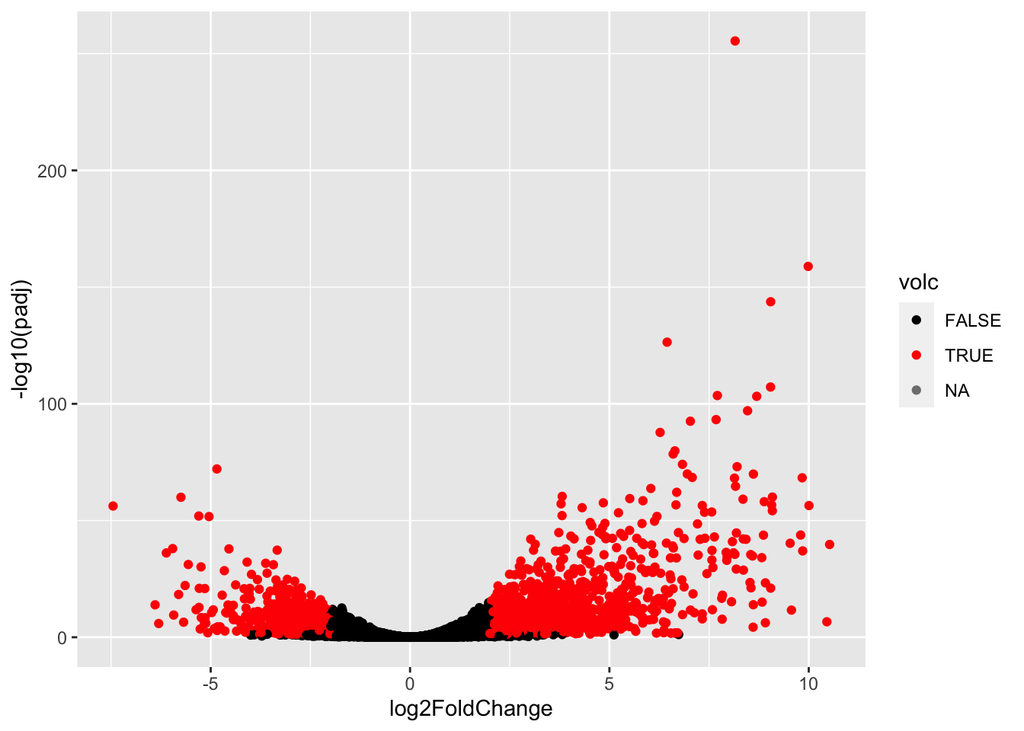

```r
#we will create an additional column that is logical to help colour points
#only padj < 0.05 and log 2 fold change ≥ 2 in either direction will be coloured
res.salm$volc <- with(res.salm, padj < 0.05 & abs(log2FoldChange) >=2)

#plotting with ggplot
ggplot(as.data.frame(res.salm), aes(x=log2FoldChange, y= -log10(padj), color= volc)) + geom_point () + scale_color_manual(values= c("black","red"))
```

Questions:

1. Where are the most interesting genes present? What colour is it indicated in? How is the MA plot different from a volcano plot?

Heatmaps for genes are normally plotted using z scores (you can google what it is). We will use the rlog transformed read count for this.

```r
#converting to a suitable format
rld_mat <- assay(rld)

#calculating the z score for rld_mat
rld.z <- t(scale(t(rld_mat), center = T, scale = T))
```

We will now perform some formatting, so we have all information needed for the heatmap.

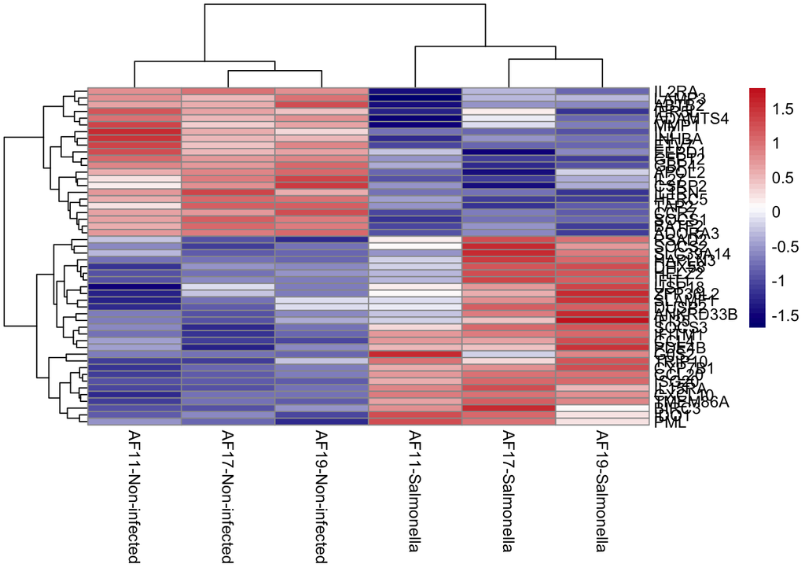

```r
#setting labels to the column names of rld.z
colnames(rld.z) <-  paste(rld$Individual, rld$Infection, sep="-")

#subsetting rld.z to have only the DEGs
top.z <- rld.z[rownames(rld.z) %in% res.salm.de$gene_id,]

#ordering content by ensembl gene ids
top.z <- top.z[order(rownames(top.z)),]


#setting labels row names of top.z to be gene names instead of ensembl ids
rownames(top.z) <- res.salm.de$gene_name

#loading pheatmap
library(pheatmap)

#plotting heat map of z scores for top 50 DEGs
pheatmap(top.z[1:50,], color = colorRampPalette(c("navy", "white", "firebrick3"))(50))
```

Questions:

1. How do you interpret this plot? What does the colour scale indicate?

# E. Functional analysis:

Finally, let’s look at some of the function of these DEGs. For the DEGs, it would be interesting to see if any particular class of genes are enriched. There are many ways and many packages that will help with this. We will look at GO term enrichment with the package clusterprofiler, for which we will use annotation from the package org.Hs.eg.db. We will check if the DEGs are enriched for any gene categories in comparison to the total genes we included in our analysis. To find out details about any GO term, enter the GO ID here: http://geneontology.org/ .

```r
#loading packages
library(clusterProfiler)
library(org.Hs.eg.db)
```

We will ontology terms from the category of “Biological Processes” (BP).

```r
#calculating enrichment scores for the DEGs in salmonella infection; will take a few seconds
salm.go <- enrichGO(res.salm.de$gene_id, universe=row.names(dds) ,OrgDb = org.Hs.eg.db, ont="BP", pvalueCutoff = 0.05, pAdjustMethod="BH", keyType = "ENSEMBL")

#inspect object
head(salm.go)
```

```
##                    ID                              Description GeneRatio
## GO:0019221 GO:0019221      cytokine-mediated signaling pathway  220/3941
## GO:0002237 GO:0002237 response to molecule of bacterial origin  166/3941
## GO:0031349 GO:0031349  positive regulation of defense response  203/3941
## GO:0032496 GO:0032496           response to lipopolysaccharide  153/3941
## GO:0071222 GO:0071222  cellular response to lipopolysaccharide  115/3941
## GO:0009615 GO:0009615                        response to virus  183/3941
##              BgRatio       pvalue     p.adjust       qvalue
## GO:0019221 456/13687 3.721725e-19 2.191352e-15 1.686137e-15
## GO:0002237 327/13687 2.322201e-17 5.233163e-14 4.026662e-14
## GO:0031349 424/13687 2.666354e-17 5.233163e-14 4.026662e-14
## GO:0032496 301/13687 3.650876e-16 5.374089e-13 4.135097e-13
## GO:0071222 209/13687 1.232052e-15 1.450864e-12 1.116369e-12
## GO:0009615 385/13687 2.503119e-15 2.456394e-12 1.890074e-12
##                                                                                                                                                                                                                                                                                                          …
## GO:0019221 ENSG00000126353/ENSG00000136689/ENSG00000115009/ENSG00000185…
## GO:0002237                                                                                                                                                                                                                                                                                               …
## GO:0031349                                                                                                                                                                                                                                                                                 ENSG0000012635…
## GO:0032496                                                                                                                                                                                                                                                                                               …
## GO:0071222                                                                                                                                                                                                                                                                                               …
## GO:0009615                                                                                                                                                                                                                                                                                               …
##            Count
## GO:0019221   220
## GO:0002237   166
## GO:0031349   203
## GO:0032496   153
## GO:0071222   115
## GO:0009615   183
```

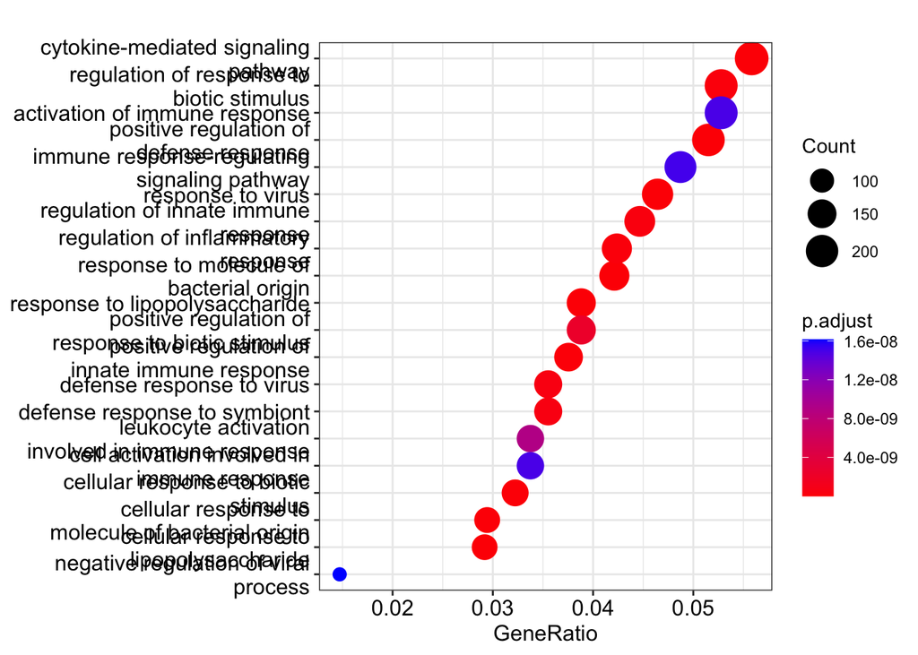

```r
#plotting go terms; limiting to top 20 categories
dotplot(salm.go, showCategory=20)
```

Questions: 1. What biological processes do you think are differentially regulated between the two conditions?